# DSCI 531 Week 2：ggplot2 可运行演示

这不是 Lab 答案。它只演示 Week 2：**summary 与 spread、counts/proportions、histogram、KDE、joint distributions、EDA 与 missingness**。

运行：

```bash
Rscript -e 'rmarkdown::render("DSCI_531/notes/week2-ggplot-demo.Rmd")'
```

## 0. Setup：内置合成数据

```r
library(tidyverse)
theme_set(theme_minimal(base_size = 13))

observations <- tidyr::expand_grid(device_num = 1:20, day = 1:12) |>
  mutate(
    device = sprintf("D%02d", device_num),
    region = factor(c("North", "Central", "South")[(device_num - 1) %% 3 + 1],
                    levels = c("North", "Central", "South")),
    load = 20 + 1.7 * day + recode(region, North = 3, Central = 0, South = -2) +
      ((device_num * 17 + day * 7) %% 11 - 5) / 2,
    signal = 4 + 0.38 * load + 2 * sin(day * pi / 6) +
      recode(region, North = 1.5, Central = 0, South = -1) +
      ((device_num * 5 + day * 3) %% 7 - 3) * 0.4,
    events = pmax(0, round(load / 6 + recode(region, North = 2, Central = 1, South = 0) +
                           ((device_num + day) %% 3 - 1))),
    signal = if_else(device_num == 7 & day == 8, signal + 12, signal),
    signal = if_else(
      (device_num == 3 & day == 4) |
      (device_num == 8 & day == 9) |
      (device_num == 14 & day == 2) |
      (device_num == 19 & day == 11),
      NA_real_, signal),
    alert = case_when(is.na(signal) ~ "missing", signal >= 22 ~ "alert", TRUE ~ "ok")
  ) |>
  select(device, device_num, region, day, load, signal, events, alert)

stopifnot(nrow(observations) == 240, sum(is.na(observations$signal)) == 4)
glimpse(observations)
```

```
## Rows: 240
## Columns: 8
## $ device     <chr> "D01", "D01", "D01", "D01", "D01", "D01", "D01", "D01", "D0…
## $ device_num <int> 1, 1, 1, 1, 1, 1, 1, 1, 1, 1, 1, 1, 2, 2, 2, 2, 2, 2, 2, 2,…
## $ region     <fct> North, North, North, North, North, North, North, North, Nor…
## $ day        <int> 1, 2, 3, 4, 5, 6, 7, 8, 9, 10, 11, 12, 1, 2, 3, 4, 5, 6, 7,…
## $ load       <dbl> 23.2, 28.4, 28.1, 27.8, 33.0, 32.7, 32.4, 37.6, 37.3, 42.5,…
## $ signal     <dbl> 14.51600, 18.42405, 16.97800, 17.79605, 20.24000, 17.52600,…
## $ events     <dbl> 7, 6, 7, 8, 6, 7, 8, 7, 8, 10, 8, 9, 4, 5, 6, 5, 6, 7, 5, 6…
## $ alert      <chr> "ok", "ok", "ok", "ok", "ok", "ok", "ok", "ok", "ok", "ok",…
```

```r
head(observations, 8)
```

```
## # A tibble: 8 × 8
##   device device_num region   day  load signal events alert
##   <chr>       <int> <fct>  <int> <dbl>  <dbl>  <dbl> <chr>
## 1 D01             1 North      1  23.2   14.5      7 ok
## 2 D01             1 North      2  28.4   18.4      6 ok
## 3 D01             1 North      3  28.1   17.0      7 ok
## 4 D01             1 North      4  27.8   17.8      8 ok
## 5 D01             1 North      5  33     20.2      6 ok
## 6 D01             1 North      6  32.7   17.5      7 ok
## 7 D01             1 North      7  32.4   17.6      8 ok
## 8 D01             1 North      8  37.6   17.3      7 ok
```

一行是一台设备在一天的一次观测。`signal` 有 4 个缺失值，并人为加入 1 个极端高值，便于观察 summary 会隐藏什么。

## 1. Central tendency、spread 与 underlying observations

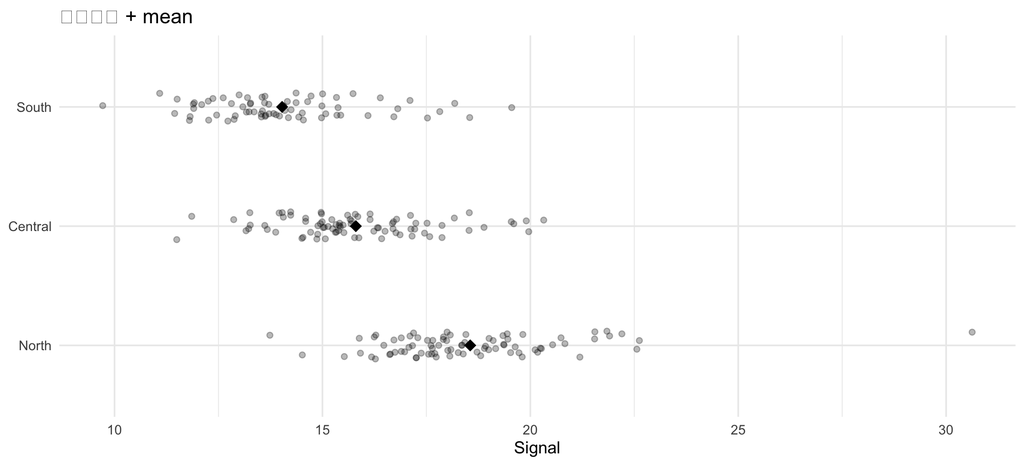

```r
raw_and_mean <- ggplot(observations, aes(signal, region)) +
  geom_jitter(width = 0, height = 0.12, alpha = 0.28, na.rm = TRUE) +
  stat_summary(fun = mean, geom = "point", shape = 18, size = 4,
               color = "black", na.rm = TRUE) +
  labs(title = "原始观测 + mean", x = "Signal", y = NULL)

boxplots <- ggplot(observations, aes(signal, region, fill = region)) +
  geom_boxplot(alpha = 0.5, na.rm = TRUE, show.legend = FALSE) +
  labs(title = "Median、IQR、whiskers 与 beyond-whisker points",
       x = "Signal", y = NULL)

raw_and_mean
```

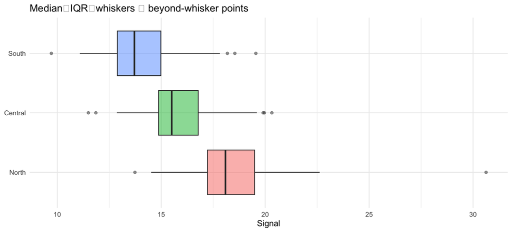

```r
boxplots
```

- Mean 使用所有值，容易受极端值影响；median 更稳健，但可能忽略真正重要的极端事件。
- Boxplot 的箱体是 Q1–Q3，中线是 median；默认 whiskers 到 1.5 IQR 范围内的最远点。Beyond-whisker point 不自动等于错误。
- 这里的 spread 描述 observations，不是 mean 的 uncertainty。

## 2. Counts、proportions 与 denominator

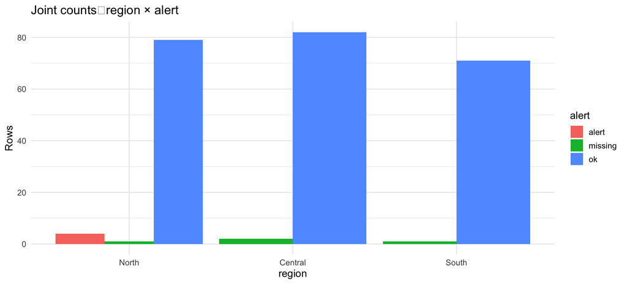

```r
count_plot <- ggplot(observations, aes(region, fill = alert)) +
  geom_bar(position = "dodge") +
  labs(title = "Joint counts：region × alert", y = "Rows")

conditional_plot <- ggplot(observations, aes(region, fill = alert)) +
  geom_bar(position = "fill") +
  scale_y_continuous(labels = scales::label_percent()) +
  labs(title = "Conditional proportions：alert within region",
       y = "Share within region")

count_plot
```

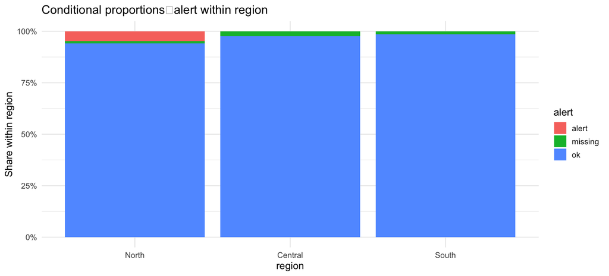

```r
conditional_plot
```

```r
count_table <- observations |>
  count(region, alert) |>
  group_by(region) |>
  mutate(within_region = n / sum(n)) |>
  ungroup()
count_table
```

```
## # A tibble: 7 × 4
##   region  alert       n within_region
##   <fct>   <chr>   <int>         <dbl>
## 1 North   alert       4        0.0476
## 2 North   missing     1        0.0119
## 3 North   ok         79        0.940
## 4 Central missing     2        0.0238
## 5 Central ok         82        0.976
## 6 South   missing     1        0.0139
## 7 South   ok         71        0.986
```

- Joint count = 一个 `(region, alert)` cell；marginal count = row/column total。
- Joint proportion 除以 grand total；conditional proportion 除以指定 row/column total。
- `position = "fill"` 隐藏了不同 region 的原始样本量，因此 counts 和 proportions 回答不同问题。

## 3. Histogram：bin width 和 origin 都会改变图形

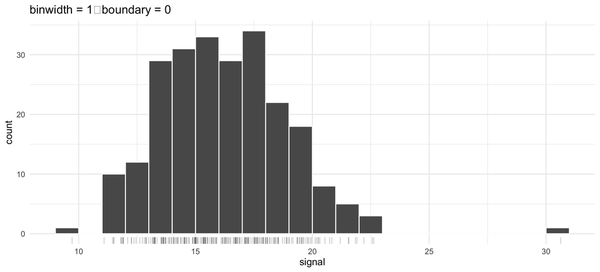

```r
hist_narrow <- ggplot(observations, aes(signal)) +
  geom_histogram(binwidth = 1, boundary = 0, color = "white", na.rm = TRUE) +
  geom_rug(alpha = 0.18, na.rm = TRUE) +
  labs(title = "binwidth = 1；boundary = 0")

hist_wide <- ggplot(observations, aes(signal)) +
  geom_histogram(binwidth = 4, boundary = 0, color = "white", na.rm = TRUE) +
  geom_rug(alpha = 0.18, na.rm = TRUE) +
  labs(title = "binwidth = 4；boundary = 0")

hist_shifted <- ggplot(observations, aes(signal)) +
  geom_histogram(binwidth = 4, boundary = 2, color = "white", na.rm = TRUE) +
  geom_rug(alpha = 0.18, na.rm = TRUE) +
  labs(title = "同样 binwidth，boundary 改成 2")

hist_narrow
```

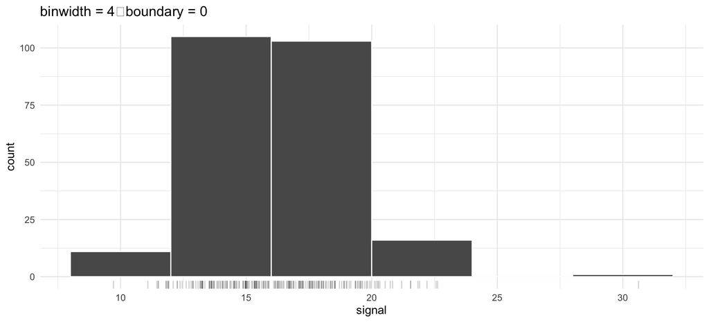

```r
hist_wide
```

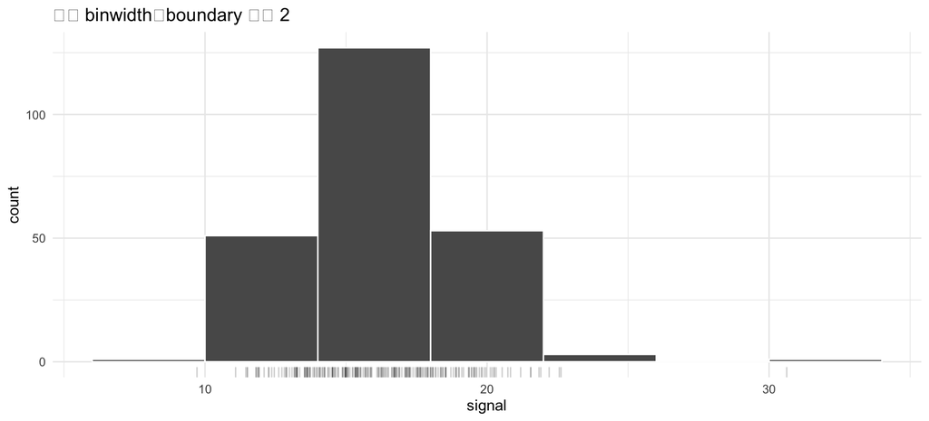

```r
hist_shifted
```

Histogram 先分 bin，再数每个 interval 的 observations。不要只看一种 width/origin；尝试按变量单位选择几个合理值，检查 peak/gap 是否稳定。

## 4. KDE、bandwidth 与 grouped distributions

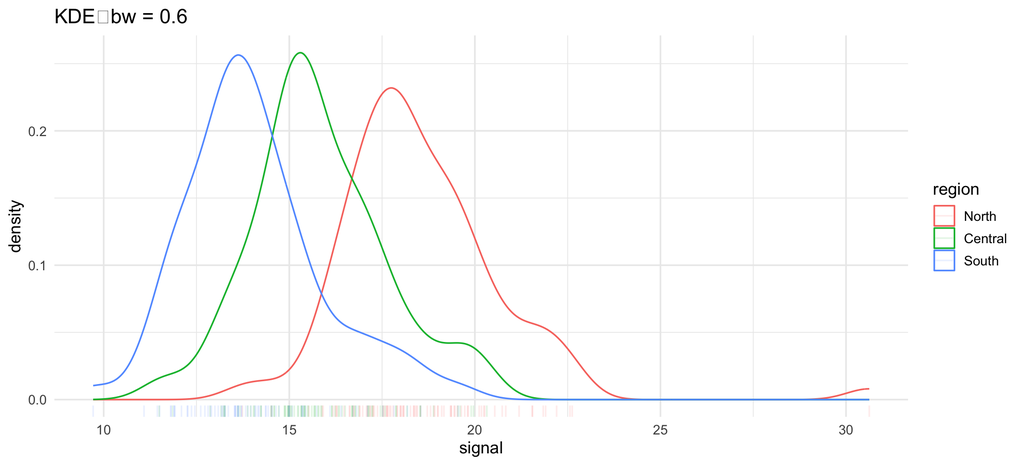

```r
kde_narrow <- ggplot(observations, aes(signal, color = region)) +
  geom_density(bw = 0.6, na.rm = TRUE) +
  geom_rug(alpha = 0.12, na.rm = TRUE) +
  labs(title = "KDE：bw = 0.6")

kde_smooth <- ggplot(observations, aes(signal, color = region)) +
  geom_density(bw = 2.0, na.rm = TRUE) +
  geom_rug(alpha = 0.12, na.rm = TRUE) +
  labs(title = "KDE：bw = 2.0")

violins <- ggplot(observations, aes(region, signal, fill = region)) +
  geom_violin(trim = FALSE, alpha = 0.45, na.rm = TRUE, show.legend = FALSE) +
  geom_boxplot(width = 0.13, outlier.shape = NA, na.rm = TRUE) +
  labs(title = "Violin（mirrored KDE）+ boxplot", x = NULL, y = "Signal")

kde_narrow
```

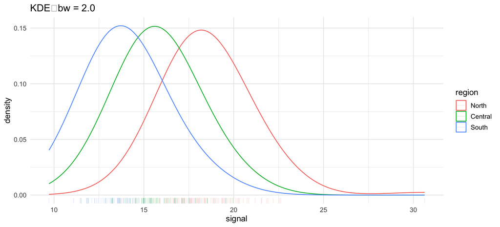

```r
kde_smooth
```

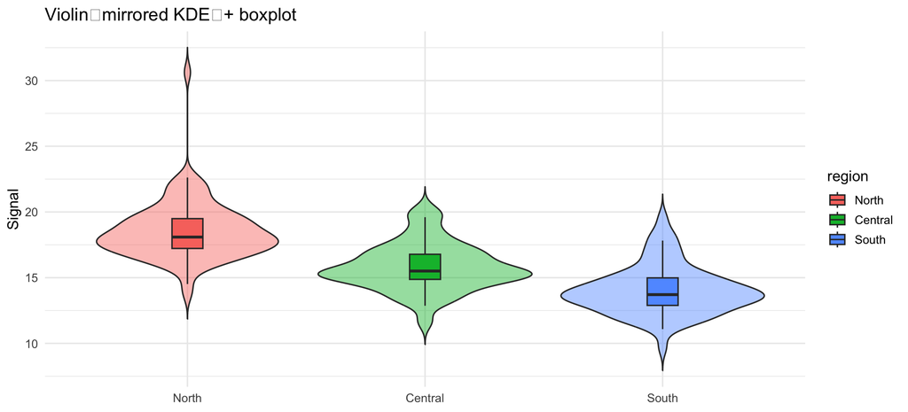

```r
violins
```

Normalized KDE 每组总面积为 1；高度是 probability density per x-unit，不是 point probability/count。小 bandwidth 显示更多细节/噪声，大 bandwidth 更平滑但可能隐藏 modes。光滑曲线不证明 n 大；结合 rug 和 group counts。

## 5. Joint distributions：margins 不能重建 combinations

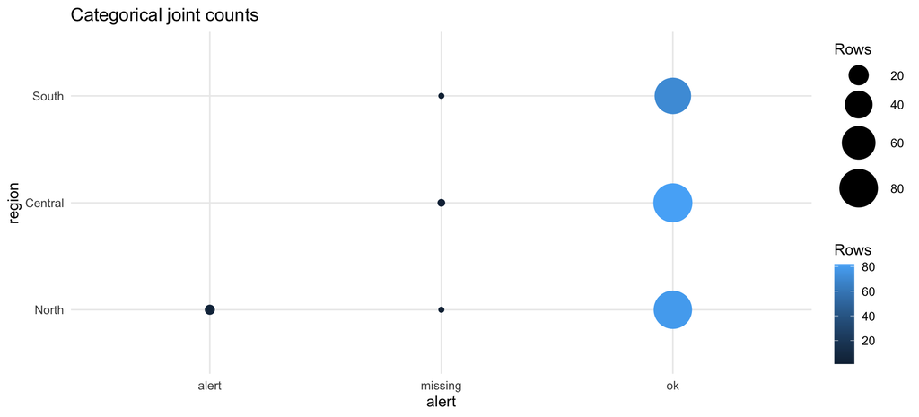

```r
category_joint <- observations |>
  count(region, alert) |>
  ggplot(aes(alert, region, size = n, color = n)) +
  geom_point() +
  scale_size_area(max_size = 15) +
  labs(title = "Categorical joint counts", size = "Rows", color = "Rows")

points <- ggplot(observations, aes(load, signal)) +
  geom_point(alpha = 0.25, na.rm = TRUE) +
  labs(title = "Scatter：overlap 可能掩盖局部密度")

binned <- ggplot(observations, aes(load, signal)) +
  geom_bin_2d(binwidth = c(3, 2), na.rm = TRUE) +
  labs(title = "2-D histogram：cell color = joint count")

category_joint
```

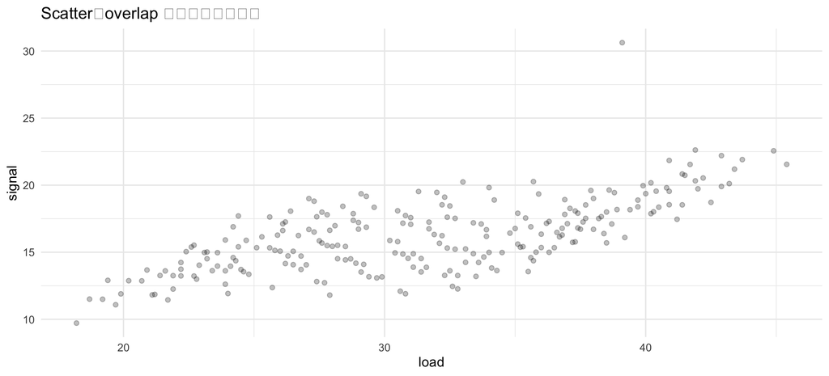

```r
points
```

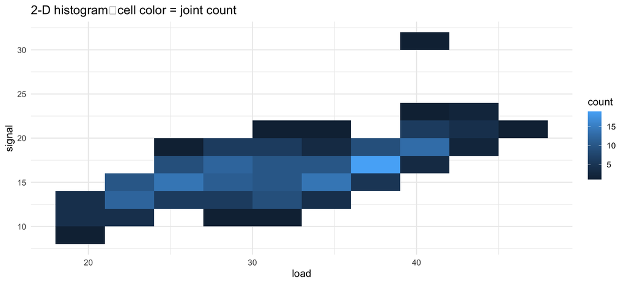

```r
binned
```

分别知道 `load` 和 `signal` 的 marginal distributions，不能确定每个 `(load, signal)` cell 的 joint count。Scatter 饱和时换 2-D histogram；同样要改变 x/y bin width 做 sensitivity check。

## 6. EDA：distribution、relationship、missingness

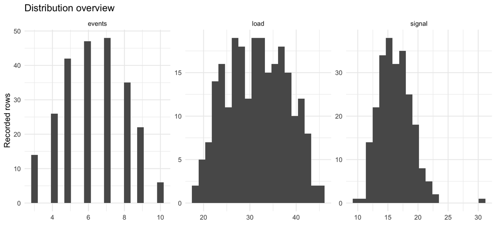

```r
measurements_long <- observations |>
  pivot_longer(c(load, signal, events), names_to = "measurement", values_to = "value")

distribution_gallery <- ggplot(measurements_long, aes(value)) +
  geom_histogram(bins = 20, na.rm = TRUE) +
  facet_wrap(vars(measurement), scales = "free", nrow = 1) +
  labs(title = "Distribution overview", x = NULL, y = "Recorded rows")

recorded_share <- observations |>
  group_by(day, region) |>
  summarise(recorded_share = mean(!is.na(signal)), .groups = "drop")

missing_plot <- ggplot(recorded_share, aes(day, region, fill = recorded_share)) +
  geom_tile(color = "white") +
  scale_fill_viridis_c(limits = c(0, 1), labels = scales::label_percent()) +
  scale_x_continuous(breaks = 1:12) +
  labs(title = "Recorded-share heatmap", fill = "Recorded share")

outcome_gallery <- observations |>
  pivot_longer(c(load, events), names_to = "measurement", values_to = "value") |>
  ggplot(aes(value, signal, color = region)) +
  geom_point(alpha = 0.3, na.rm = TRUE) +
  facet_wrap(vars(measurement), scales = "free_x", nrow = 1) +
  labs(title = "Outcome-focused EDA：signal 与候选变量", x = NULL, y = "Signal") +
  theme(legend.position = "bottom")

distribution_gallery
```

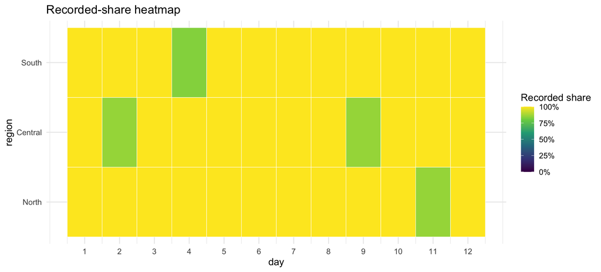

```r
missing_plot
```

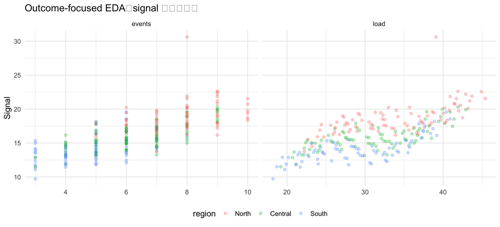

```r
outcome_gallery
```

EDA reasoning trail：

1. **Expectation：**根据文档、采集过程或领域知识，原本预期什么？
2. **Observation：**实际看到什么？每张图包含哪些有效 rows？
3. **Competing explanations：**subgroups、missingness、录入、极端值、bin/bandwidth 都可能解释。
4. **Discriminating check：**哪项 follow-up 能区分解释？是否需要 data provider/provenance？
5. **Narrow conclusion + unresolved：**只写当前证据支持的最窄结论；“机制未确认”可以是正确结果。

## 7. 建议你亲手修改

- `geom_boxplot()` 上加入/移除 raw points，观察 summary 隐藏什么。
- 将 bar 的 `position` 在 `"dodge"`、`"stack"`、`"fill"` 间切换并说明 denominator。
- 修改 histogram 的 `binwidth` 和 `boundary`。
- 修改 KDE 的 `bw`，并比较 group n。
- 修改 2-D histogram 的两个 `binwidth`。
- 把 missing value 填成 0，观察图怎样改变；然后解释为什么这不是中立处理。